# Namibia Cluster RCT Study log

Weilu

2022-09-21

Clik to get this Log file-> [Namibia Cluster RCT Study log.html](https://github.com/VEuPathDB/ApiCommonData/tree/master/Load/ontology/Gates/namibia/doc)

### Datasets information

**Total datasets:** 5  
**Recevied date:** 03/2022  
**Datasets from:** Namibia study team  
**Dataset stats:**

Snapshot of datasets

| No. | Dataset_name | N_total | Data_level |
| --- | --- | --- | --- |
| 1 | EA_level_dataset.csv | 102 | Community |
| 2 | endline_individual_cross_sectional_forclinepidb.csv | 4424 | Participant |
| 3 | Individual_deidentified_forclinepidb.csv | 9845 | Participant |
| 4 | RAVC_data_deidentified.csv | 923 | Housedhold |
| 5 | SDSS_index_deidentified_forclinepidb.csv | 2349 | Participant |

### Current idMap

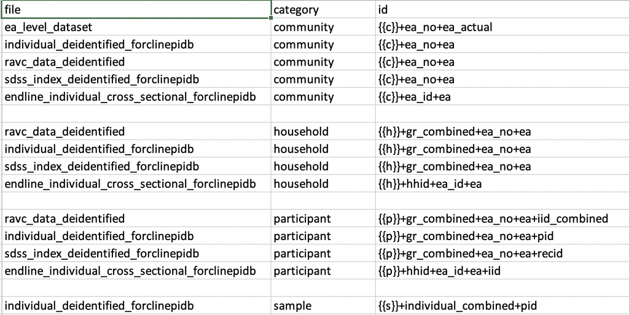

### ID chcecking

#### 1.ID scan

```
## [1] "EA_level_dataset.csv"
```

```
##      ea_no ea_actual
## 1 10499003
## 2 10499004
## 3 10499005      RV01
```

```
## [1] "endline_individual_cross_sectional_forclinepidb.csv"
```

```
##      ea_id   ea     hhid      iid
## 1 10699015 RV13 XSHH1233 XSID0001
## 2 10699015 RV13 XSHH1233 XSID0002
## 3 10699015 RV13 XSHH1233 XSID0003
```

```
## [1] "Individual_deidentified_forclinepidb.csv"
```

```
##      ea_no   ea  gr_combined   pid
## 1       NA RO01 ZA04-0243-03 pid-1
## 2       NA RO01 ZA04-0262-09 pid-2
## 3 10699019 RO14 ZA06-2274-09 pid-3
```

```
## [1] "RAVC_data_deidentified.csv"
```

```
##   ea_no   ea  gr_combined iid_combined
## 1    NA RV38 ZA04-0386-10    RV01-2614
## 2    NA RV38 ZA04-0323-06    RV01-2614
## 3    NA RV38 ZA04-0329-10    RV01-2614
```

```
## [1] "SDSS_index_deidentified_forclinepidb.csv"
```

```
##      ea_no   ea  gr_combined recid
## 1 10499014 TO02 ZA04-0573-03  2790
## 2 10699015 RV13 ZA05-4115-09  2565
## 3 10699018 RO27 ZA06-0335-10  2566
```

#### 2. ID in each dataset

EA_level_dataset.csv

| variable_name | n_missing | complete_rate | n_uniqueID | N_total |
| --- | --- | --- | --- | --- |
| ea_no | 0 | 1 | 102 | 102 |
| ea_actual | 0 | 1 | 57 | 102 |

endline_individual_cross_sectional_forclinepidb.csv

| variable_name | n_missing | complete_rate | n_uniqueID | N_total |
| --- | --- | --- | --- | --- |
| ea | 0 | 1 | 56 | 4424 |
| ea_id | 0 | 1 | 56 | 4424 |
| hhid | 0 | 1 | 1170 | 4424 |
| iid | 0 | 1 | 4424 | 4424 |

Individual_deidentified_forclinepidb.csv

| variable_name | n_missing | complete_rate | n_uniqueID | N_total |
| --- | --- | --- | --- | --- |
| ea | 0 | 1.00 | 67 | 9845 |
| ea_no | 105 | 0.99 | 55 | 9845 |
| iid_combined | 0 | 1.00 | 343 | 9845 |
| gr_combined | 0 | 1.00 | 2151 | 9845 |

RAVC_data_deidentified.csv

| variable_name | n_missing | complete_rate | n_uniqueID | N_total |
| --- | --- | --- | --- | --- |
| ea_no | 42 | 0.95 | 28 | 923 |
| ea | 0 | 1.00 | 30 | 923 |
| gr_combined | 0 | 1.00 | 872 | 923 |
| iid_combined | 0 | 1.00 | 139 | 923 |

SDSS_index_deidentified_forclinepidb.csv

[output not shown]

### Updated log

————————————–**Previous update**————————————  
1.**Dataset update:** (After meeting with study team)  
–Created new id: “pid” for obs. in “Individual_deidentified_forclinepidb.csv”  
–Add “Participant type” var for enline survey and index case datasets. values are:“Endiline survey participant” and “Index case participant”.  
2.**Multivalue confilct on community level:** Solution- Downgrade variables which belonged children datasets but were mapped as parent level. Such as the “village” that is in both community datasets and sdss dataset. In lateset conversion file, this var has two different rows that category==“Community” and “participant” respectively.  
3.**Existing issue:**  
–Geographic variables are mapped into the two different level.Eg.Category==“household” and category==“participant”.  
Question: Do we need keep both? If no, which level we should keep? *See 9/21/2022 to to list-4.*  
–Current ids in idMap do not reflect the real number of pariticipants, it just distincts each obs. to make sure they can be loaded correctly.  
———————-**9/21/2022-Group reveiw (Nupur, Danica and Weilu)** —————————–  
To do list:  
1. QA values on website; eg. Add value for 1,0 so they will not be loaded as numeric.  
2. Reconstruct datasets by adding a col “year”, then map all year related vars like xxx-2006.2007,2008 as repeated value.  
3. Tidy up unmapped value number.  
4. Drop longitudinal and latitude vars at participant level.  
5. Consider to drop the vars which the responsed obs. less than 2. Like only 1.  
6. After the updates, check with Nupur and then ask ontology team and data loading team to reload the study.

### External reference

1. [Redmine ticket](https://redmine.apidb.org/issues/40163)
2. [Namibia questions on primary keys](https://docs.google.com/document/d/1mX2I1Jrh12Y0J-ZUsAzmhiQLR-vyxKOM/edit)
3. [Namibia issue tracker](https://docs.google.com/spreadsheets/d/17syzSP8gO5EBDu0bOISjE8abMS1vEl_WGNrCMqp1obY/edit#gid=0)
4. [Namibia on qa.restricted website](https://qa.restricted.clinepidb.org/ce.restricted.qa/app/workspace/analyses/DS_f559aee789/new/variables/EUPATH_0000096/EUPATH_0053227)